# BAMF models evaluation

# DATA

Here we load the small simulated data set. For this case $p=3$.

We remove the first column of each matrix as it contains the indexes.

```r
library(tidyr)
G_ = read.csv(file = "../data/example_data_G.csv",header=TRUE)
F_ = read.csv(file = "../data/example_data_F.csv",header=TRUE)
E_ = read.csv(file = "../data/example_data_E.csv", header=TRUE)
X_ = read.csv(file = "../data/example_data_X.csv", header=TRUE)

N <- nrow(G_[,-1])
M <- ncol(X_[,-1])
P <- ncol(G_[,-1])
t <- G_[,1]
t <- (t - t[1])/(1e9)/3600
t<- diff(t)
X_ <- X_[,-1]
E_ <- E_[,-1]
F_ <- F_[,-1]
G_ <- G_[,-1]
F_ <- apply(F_, MARGIN=2, FUN = as.numeric)
par(mfrow=c(2,3))
plot(G_[,1], type="l")
plot(G_[,2], type="l")
```

```r
plot(G_[,3], type="l")
plot(F_[1,], type="l")
```

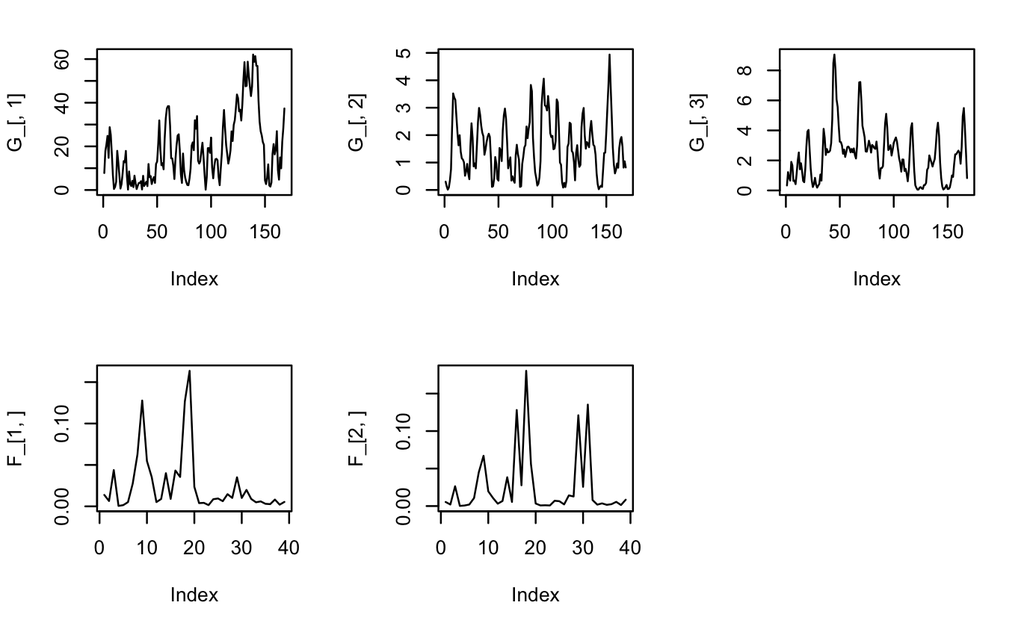

```r
plot(F_[2,], type="l")
plot(F_[3,], type="l")
```

## Data characterisation

We run a simple analysis on the data using the PCA, we use mean imputation in case of missing data.

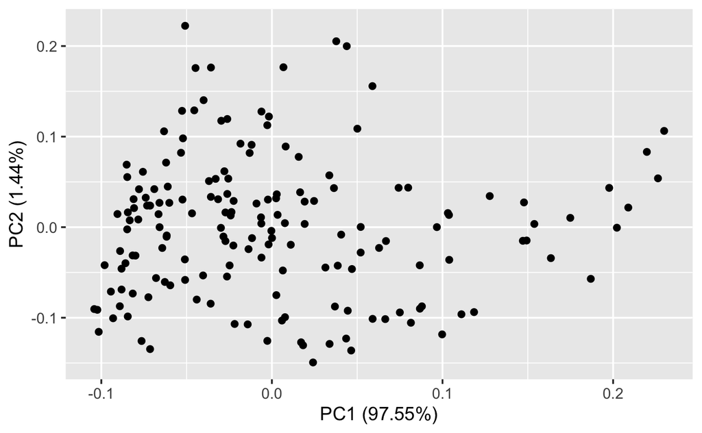

```r
library(ggfortify)
imputed_ts_data <- apply(X_, MARGIN = 2, \(x){
  y=x
  y[is.na(x)]=mean(x,na.rm=TRUE)
  y
  } )
pca <- prcomp(imputed_ts_data, scale. = TRUE)
autoplot(pca)
```

## Varimax rotation

A simple and quick way to do source separation is to use the Varimax rotations over the PCA

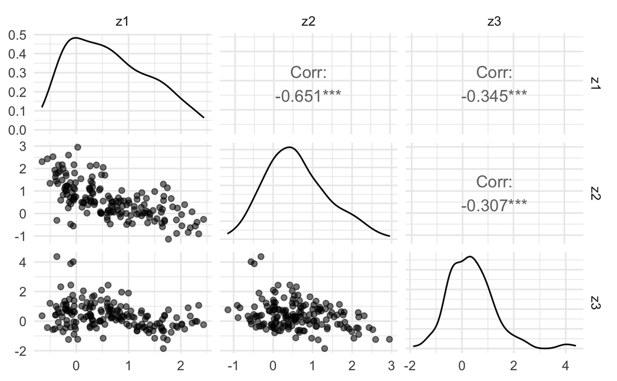

```r
library(vsp)
fa <- imputed_ts_data %>% as.matrix() %>% vsp( rank = 3)
plot_varimax_z_pairs(fa)
```

We observe weak to moderate anticorrelation between the inferred axes.

Now we correlate with the original simulated G factors

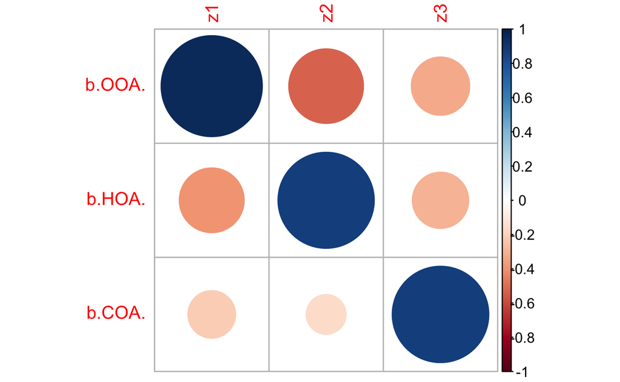

```r
library(corrplot)
corrplot(cor(G_, as.matrix(fa$Z), use = "pairwise.complete.obs"))
```

```r
par(mfrow=c(1,3))
plot(G_[,1],as.matrix(fa$Z)[,1])
plot(G_[,2],as.matrix(fa$Z)[,2])
```

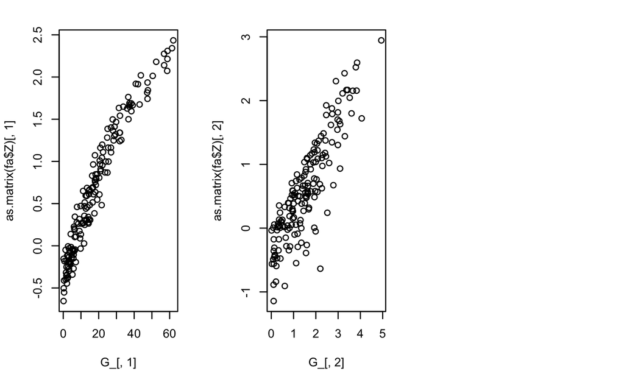

```r
plot(G_[,3],as.matrix(fa$Z)[,3])
```

### Conclusions

The sources should be well separated in this dataset.

## BAMF

Here is the original BAMF model:

```stan
functions {
  matrix vector_array_to_matrix(vector[] x) {
    matrix[size(x), rows(x[1])] y;
    for (m in 1:size(x))
      y[m] = x[m]';
    return y;
  }
}

data {
  int<lower=1> n;     // number of data points
  int<lower=1> m;     // number of dimensions
  int<lower=1> p;     // number of components
  matrix[n,m] X;      // data matrix
  matrix<lower=0>[n,m] sigma;  // separate sigma for each of the observations (!)
  vector<lower=0>[n-1] timesteps; //How much time elapses between values in X (arbitrary unit, but unit choice also affects other priors)
  real<lower=0> minerr; //Minimal error
}

transformed data {
  vector[n*m] Xv = to_vector(X);
  vector[n*m] sigmav = to_vector(sigma);
}

parameters {
  matrix<lower=0>[n,p] G; // score matrix
  simplex[m] F[p]; // loadings simplex
  vector<lower=0>[p] alpha_a; // Posterior a
  vector<lower=minerr>[p] alpha_b; // Posterior b
}

model {

  // The priors for G and F are implicitly given in the parameters section,
  //  so explicitly stating them here would only lead to unnecessary calculations
  //  (uniform priors become additive constants (in logspace), that can be ignored).

  // Column-wise autocorrelation
  for(j in 1:p) {
    G[2:,j] ~ cauchy(G[:(n-1),j], alpha_a[j]*timesteps + alpha_b[j]);
  }

  // X ~ Z = G * F
  Xv ~ normal(to_vector(G*vector_array_to_matrix(F)), sigmav);

}
```

We use cmdstan to compile and run the different models.

```r
library(cmdstanr)
set_cmdstan_path("~/cmdstan")
```

```r
file = "../models/bamf.stan"

mod <- cmdstan_model(file)
```

```r
data_list <- list(n=N, m=M , p=P, X=X_, sigma=E_, timesteps=t, minerr=
    min((E_)) / 10
)
```

## Original BAMF model

```r
fit_bamf <- mod$sample(
  data = data_list,
  seed = 123,
  chains = 4,
  parallel_chains = 4,
  refresh = 500 # print update every 500 iters
)
```

```
Running MCMC with 4 parallel chains...

Chain 1 Iteration:    1 / 2000 [  0%]  (Warmup)
```

[output not shown]

```
Chain 2 Iteration:    1 / 2000 [  0%]  (Warmup)
```

[output not shown]

```
Chain 3 Iteration:    1 / 2000 [  0%]  (Warmup)
```

[output not shown]

```
Chain 4 Iteration:    1 / 2000 [  0%]  (Warmup)
```

[output not shown]

```
Chain 2 Iteration:  500 / 2000 [ 25%]  (Warmup)
Chain 3 Iteration:  500 / 2000 [ 25%]  (Warmup)
Chain 1 Iteration:  500 / 2000 [ 25%]  (Warmup)
Chain 4 Iteration:  500 / 2000 [ 25%]  (Warmup)
Chain 2 Iteration: 1000 / 2000 [ 50%]  (Warmup)
Chain 2 Iteration: 1001 / 2000 [ 50%]  (Sampling)
Chain 3 Iteration: 1000 / 2000 [ 50%]  (Warmup)
Chain 3 Iteration: 1001 / 2000 [ 50%]  (Sampling)
Chain 1 Iteration: 1000 / 2000 [ 50%]  (Warmup)
Chain 1 Iteration: 1001 / 2000 [ 50%]  (Sampling)
Chain 4 Iteration: 1000 / 2000 [ 50%]  (Warmup)
Chain 4 Iteration: 1001 / 2000 [ 50%]  (Sampling)
Chain 2 Iteration: 1500 / 2000 [ 75%]  (Sampling)
Chain 3 Iteration: 1500 / 2000 [ 75%]  (Sampling)
Chain 2 Iteration: 2000 / 2000 [100%]  (Sampling)
Chain 2 finished in 19.1 seconds.
Chain 3 Iteration: 2000 / 2000 [100%]  (Sampling)
Chain 3 finished in 19.7 seconds.
Chain 1 Iteration: 1500 / 2000 [ 75%]  (Sampling)
Chain 4 Iteration: 1500 / 2000 [ 75%]  (Sampling)
Chain 1 Iteration: 2000 / 2000 [100%]  (Sampling)
Chain 1 finished in 27.3 seconds.
Chain 4 Iteration: 2000 / 2000 [100%]  (Sampling)
Chain 4 finished in 29.6 seconds.

All 4 chains finished successfully.
Mean chain execution time: 24.0 seconds.
Total execution time: 29.7 seconds.
```

```r
library(posterior)
fit_bamf$diagnostic_summary()
```

```
$num_divergent
[1] 0 0 0 0

$num_max_treedepth
[1] 0 0 0 0

$ebfmi
[1] 0.7565670 0.6170820 0.6955516 0.6838801
```

```r
library(bayesplot)
fit_bamf$cmdstan_diagnose()
```

```
Processing csv files: /var/folders/dm/b79x42n96dl9s8jpb4t3_9lc0000gp/T/Rtmp8Umhis/bamf-202205251104-1-89d65f.csv, /var/folders/dm/b79x42n96dl9s8jpb4t3_9lc0000gp/T/Rtmp8Umhis/bamf-202205251104-2-89d65f.csv, /var/folders/dm/b79x42n96dl9s8jpb4t3_9lc0000gp/T/Rtmp8Umhis/bamf-202205251104-3-89d65f.csv, /v…

Checking sampler transitions treedepth.
Treedepth satisfactory for all transitions.

Checking sampler transitions for divergences.
No divergent transitions found.

Checking E-BFMI - sampler transitions HMC potential energy.
E-BFMI satisfactory.

The following parameters had fewer than 0.001 effective draws per transition:
  G[1,1], G[2,1], G[3,1], G[4,1], G[5,1], G[6,1], G[7,1], G[8,1], G[9,1], G[10,1], G[11,1], G[12,1], G[13,1], G[14,1], G[15,1], G[16,1], G[17,1], G[18,1], G[19,1], G[20,1], G[21,1], G[22,1], G[23,1], G[24,1], G[25,1], G[26,1], G[27,1], G[28,1], G[29,1], G[30,1], G[31,1], G[33,1], G[35,1], G[36,1], G…
Such low values indicate that the effective sample size estimators may be biased high and actual performance may be substantially lower than quoted.

The following parameters had split R-hat greater than 1.05:
  G[1,1], G[2,1], G[3,1], G[4,1], G[5,1], G[6,1], G[7,1], G[8,1], G[9,1], G[10,1], G[11,1], G[12,1], G[13,1], G[14,1], G[15,1], G[16,1], G[17,1], G[18,1], G[19,1], G[20,1], G[21,1], G[22,1], G[23,1], G[24,1], G[25,1], G[26,1], G[27,1], G[28,1], G[29,1], G[30,1], G[31,1], G[33,1], G[34,1], G[35,1], G…
Such high values indicate incomplete mixing and biased estimation.
You should consider regularizating your model with additional prior information or a more effective parameterization.

Processing complete.
```

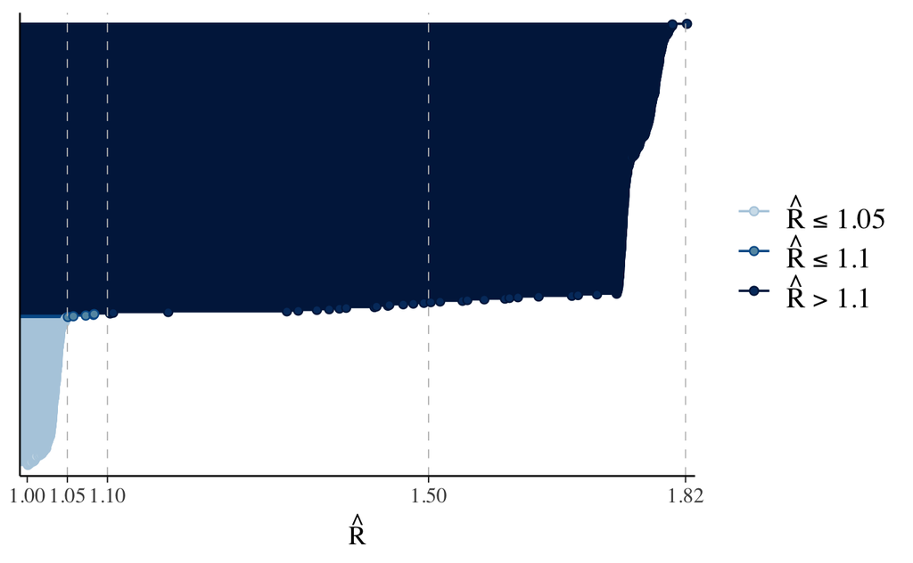

```r
mcmc_rhat(rhat(fit_bamf))
```

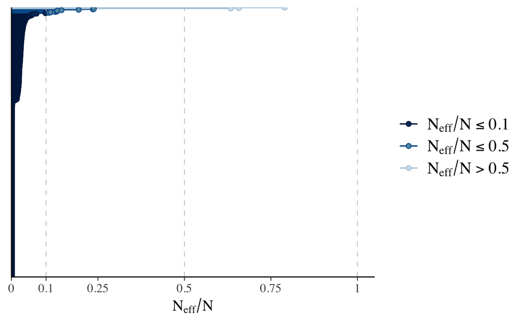

```r
mcmc_neff(neff_ratio(fit_bamf))
```

```r
draws <- fit_bamf$draws(format="df")
```

```r
library(tidyverse)
G_1 <- as_tibble(draws) %>% select( matches('G\\[\\d+,1'))
G_2 <- as_tibble(draws) %>% select( matches('G\\[\\d+,2'))
G_3 <- as_tibble(draws) %>% select( matches('G\\[\\d+,3'))
F_1 <- as_tibble(draws) %>% select( matches('F\\[1,\\d'))
F_2 <- as_tibble(draws) %>% select( matches('F\\[2,\\d'))
F_3 <- as_tibble(draws) %>% select( matches('F\\[3,\\d'))
```

let’s plot the mean over posterior samples

```r
G1_mean <- G_1 %>% colMeans()
G2_mean <- G_2 %>% colMeans()
G3_mean <- G_3 %>% colMeans()
F1_mean <- F_1 %>% colMeans()
F2_mean <- F_2 %>% colMeans()
F3_mean <- F_3 %>% colMeans()
G1_sd <- G_1 %>% as.matrix() %>% matrixStats::colSds()
G2_sd <- G_2 %>% as.matrix() %>% matrixStats::colSds()
G3_sd <- G_3 %>% as.matrix() %>% matrixStats::colSds()
F1_sd <- F_1 %>% as.matrix() %>% matrixStats::colSds()
F2_sd <- F_2 %>% as.matrix() %>% matrixStats::colSds()
F3_sd <- F_3 %>% as.matrix() %>% matrixStats::colSds()
par(mfrow=c(2,3))
plot(G1_mean, type ="l")
plot(G2_mean, type ="l")
```

```r
plot(G3_mean, type ="l")
plot(F1_mean, type ="l")
```

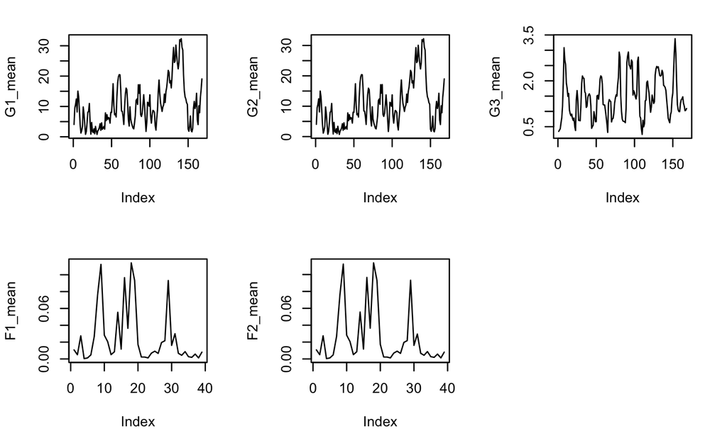

```r
plot(F2_mean, type ="l")
plot(F3_mean, type ="l")
```

Here we plot the correlation between the posterior means and the original G values

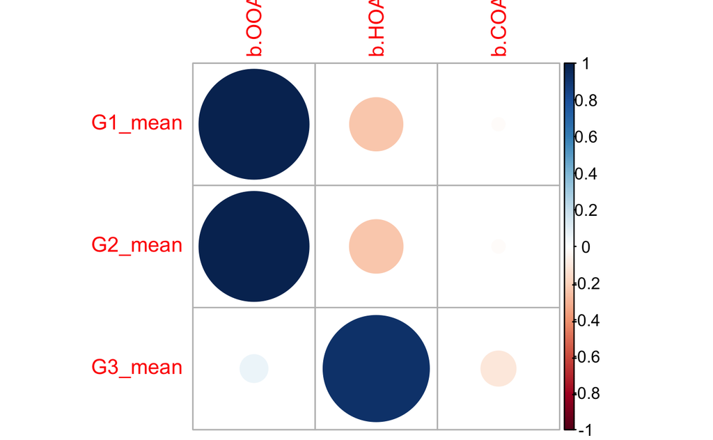

```r
corrplot(cor(cbind(G1_mean,G2_mean,G3_mean),G_))
```

Here we plot the posterior means vs the original values of G and F

```r
par(mfrow=c(2,3))
plot(G_[,1],G1_mean)
plot(G_[,2],G2_mean)
```

```r
plot(G_[,3],G3_mean)
plot(F_[1,],F1_mean)
```

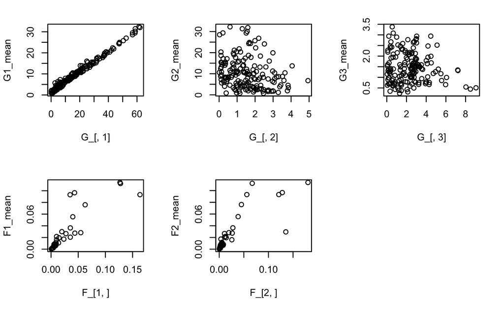

```r
plot(F_[2,],F2_mean)
plot(F_[3,],F3_mean)
```

Here we plot the z-scores for G and F, everything should be between 2 and -2 (95% confidence interval)

```r
par(mfrow=c(2,3))
plot((G_[,1]-G1_mean)/G1_sd, main="z-scores")
abline(h=2)
```

```r
abline(h=-2)
plot((G_[,2]-G2_mean)/G2_sd)
```

```r
abline(h=2)
abline(h=-2)
```

```r
plot((G_[,3]-G3_mean)/G3_sd)
abline(h=2)
```

```r
abline(h=-2)
plot((F_[1,]-F1_mean)/F1_sd)
```

```r
abline(h=2)
abline(h=-2)
```

```r
plot((F_[2,]-F2_mean)/F2_sd)
abline(h=2)
```

```r
abline(h=-2)
plot((F_[3,]-F3_mean)/F3_sd)
```

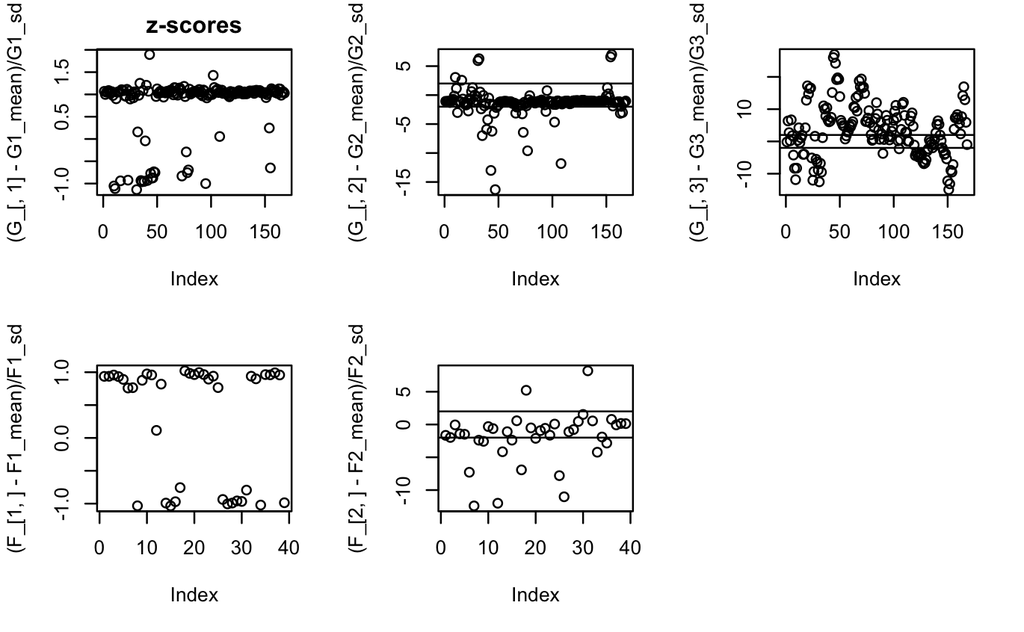

```r
abline(h=2)
abline(h=-2)
```

Let’s define some functions to carry the above diagnostics

```r
quick_diagnostic_plots <- function(stan_fit){
  stan_fit$diagnostic_summary()
  stan_fit$cmdstan_diagnose()
  mcmc_rhat(rhat(fit_bamf))
  mcmc_neff(neff_ratio(fit_bamf))
  draws <- stan_fit$draws(format="df")
  G_1 <- as_tibble(draws) %>% select( matches('G\\[\\d+,1'))
  G_2 <- as_tibble(draws) %>% select( matches('G\\[\\d+,2'))
  G_3 <- as_tibble(draws) %>% select( matches('G\\[\\d+,3'))
  F_1 <- as_tibble(draws) %>% select( matches('F\\[1,\\d'))
  F_2 <- as_tibble(draws) %>% select( matches('F\\[2,\\d'))
  F_3 <- as_tibble(draws) %>% select( matches('F\\[3,\\d'))
  G1_mean <- G_1 %>% colMeans()
  G2_mean <- G_2 %>% colMeans()
  G3_mean <- G_3 %>% colMeans()
  F1_mean <- F_1 %>% colMeans()
  F2_mean <- F_2 %>% colMeans()
  F3_mean <- F_3 %>% colMeans()
  G1_sd <- G_1 %>% as.matrix() %>% matrixStats::colSds()
  G2_sd <- G_2 %>% as.matrix() %>% matrixStats::colSds()
  G3_sd <- G_3 %>% as.matrix() %>% matrixStats::colSds()
  F1_sd <- F_1 %>% as.matrix() %>% matrixStats::colSds()
  F2_sd <- F_2 %>% as.matrix() %>% matrixStats::colSds()
  F3_sd <- F_3 %>% as.matrix() %>% matrixStats::colSds()
  par(mfrow=c(2,3))
  plot(G1_mean, type ="l")
  plot(G2_mean, type ="l")
  plot(G3_mean, type ="l")
  plot(F1_mean, type ="l")
  plot(F2_mean, type ="l")
  plot(F3_mean, type ="l")
  dev.off()
  corrplot(cor(cbind(G1_mean,G2_mean,G3_mean),G_))
  dev.off()
  par(mfrow=c(2,3))
  plot(G_[,1],G1_mean)
  plot(G_[,2],G2_mean)
  plot(G_[,3],G3_mean)
  plot(F_[1,],F1_mean)
  plot(F_[2,],F2_mean)
  plot(F_[3,],F3_mean)
  dev.off()
  par(mfrow=c(2,3))
  plot((G_[,1]-G1_mean)/G1_sd)
  abline(h=2)
  abline(h=-2)
  plot((G_[,2]-G2_mean)/G2_sd)
  abline(h=2)
  abline(h=-2)
  plot((G_[,3]-G3_mean)/G3_sd)
  abline(h=2)
  abline(h=-2)
  plot((F_[1,]-F1_mean)/F1_sd)
  abline(h=2)
  abline(h=-2)
  plot((F_[2,]-F2_mean)/F2_sd)
  abline(h=2)
  abline(h=-2)
  plot((F_[3,]-F3_mean)/F3_sd)
  abline(h=2)
  abline(h=-2)
}

quick_diagnostic_plots_with_F <- function(stan_fit){
  stan_fit$diagnostic_summary()
  stan_fit$cmdstan_diagnose()
  #mcmc_rhat(rhat(stan_fit))
  #mcmc_neff(neff_ratio(stan_fit))
  draws <- stan_fit$draws(format="df")
  G_1 <- as_tibble(draws) %>% select( matches('G\\[\\d+,1'))
  G_2 <- as_tibble(draws) %>% select( matches('G\\[\\d+,2'))
  G_3 <- as_tibble(draws) %>% select( matches('G\\[\\d+,3'))
  G1_mean <- G_1 %>% colMeans()
  G2_mean <- G_2 %>% colMeans()
  G3_mean <- G_3 %>% colMeans()
  G1_sd <- G_1 %>% as.matrix() %>% matrixStats::colSds()
  G2_sd <- G_2 %>% as.matrix() %>% matrixStats::colSds()
  G3_sd <- G_3 %>% as.matrix() %>% matrixStats::colSds()
  par(mfrow=c(1,3))
  plot(G1_mean, type ="l")
  plot(G2_mean, type ="l")
  plot(G3_mean, type ="l")
  dev.off()
  corrplot(cor(cbind(G1_mean,G2_mean,G3_mean),G_))
  dev.off()
  par(mfrow=c(2,3))
  plot(G_[,1],G1_mean)
  plot(G_[,2],G2_mean)
  plot(G_[,3],G3_mean)
  dev.off()
  par(mfrow=c(2,3))
  plot((G_[,1]-G1_mean)/G1_sd)
  plot((G_[,2]-G2_mean)/G2_sd)
  plot((G_[,3]-G3_mean)/G3_sd)
}


quick_diagnostic_plots_MAP<- function(stan_fit){
  draws <- stan_fit$draws(format="df")
  G_1 <- as_tibble(draws) %>% select( matches('G\\[\\d+,1'))
  G_2 <- as_tibble(draws) %>% select( matches('G\\[\\d+,2'))
  G_3 <- as_tibble(draws) %>% select( matches('G\\[\\d+,3'))
  F_1 <- as_tibble(draws) %>% select( matches('F\\[1,\\d'))
  F_2 <- as_tibble(draws) %>% select( matches('F\\[2,\\d'))
  F_3 <- as_tibble(draws) %>% select( matches('F\\[3,\\d'))
  G1_mean <- G_1 %>% as.matrix()
  G2_mean <- G_2 %>% as.matrix()
  G3_mean <- G_3%>% as.matrix()
   F1_mean <- F_1%>% as.matrix()
  F2_mean <- F_2 %>% as.matrix()
  F3_mean <- F_3 %>% as.matrix()
  par(mfrow=c(2,3))
  plot(t(G1_mean),type="l")
  plot(t(G2_mean),type="l")
  plot(t(G3_mean),type="l")
  plot(t(F1_mean),type="l")
  plot(t(F2_mean),type="l")
  plot(t(F3_mean),type="l")
  dev.off()
  corrplot(cor(cbind(t(G1_mean),t(G2_mean),t(G3_mean)),G_))
  dev.off()
  par(mfrow=c(2,3))
  plot(G_[,1],t(G1_mean))
  plot(G_[,2],t(G2_mean))
  plot(G_[,3],t(G3_mean))
  plot(F_[1,],t(F1_mean))
  plot(F_[2,],t(F2_mean))
  plot(F_[3,],t(F3_mean))
  dev.off()
}
```

## Look at the simplex: BAMF_F

Let’s include the simplex as an input:

```stan
functions {
  matrix vector_array_to_matrix(vector[] x) {
    matrix[size(x), rows(x[1])] y;
    for (m in 1:size(x))
      y[m] = x[m]';
    return y;
  }
}

data {
  int<lower=1> n;     // number of data points
  int<lower=1> m;     // number of dimensions
  int<lower=1> p;     // number of components
  matrix[n,m] X;      // data matrix
  matrix<lower=0>[n,m] sigma;  // separate sigma for each of the observations (!)
  vector<lower=0>[n-1] timesteps; //How much time elapses between values in X (arbitrary unit, but unit choice also affects other priors)
  real<lower=0> minerr; //Minimal error
  matrix<lower=0>[p,m] F; // now we use the original F as data
}

transformed data {
  vector[n*m] Xv = to_vector(X);
  vector[n*m] sigmav = to_vector(sigma);
}

parameters {
  matrix<lower=0>[n,p] G; // score matrix
  vector<lower=0>[p] alpha_a; // Posterior a
  vector<lower=minerr>[p] alpha_b; // Posterior b
}

model {

  // The priors for G and F are implicitly given in the parameters section,
  //  so explicitly stating them here would only lead to unnecessary calculations
  //  (uniform priors become additive constants (in logspace), that can be ignored).

  // Column-wise autocorrelation
  for(j in 1:p) {
    G[2:,j] ~ cauchy(G[:(n-1),j], alpha_a[j]*timesteps + alpha_b[j]);
  }

  // X ~ Z = G * F
  Xv ~ normal(to_vector(G*F), sigmav);

}
```

And now lets sample

```
Processing csv files: /var/folders/dm/b79x42n96dl9s8jpb4t3_9lc0000gp/T/Rtmp8Umhis/bamf_F-202205251048-1-7a2ea9.csv, /var/folders/dm/b79x42n96dl9s8jpb4t3_9lc0000gp/T/Rtmp8Umhis/bamf_F-202205251048-2-7a2ea9.csv, /var/folders/dm/b79x42n96dl9s8jpb4t3_9lc0000gp/T/Rtmp8Umhis/bamf_F-202205251048-3-7a2ea9.c…

Checking sampler transitions treedepth.
Treedepth satisfactory for all transitions.

Checking sampler transitions for divergences.
No divergent transitions found.

Checking E-BFMI - sampler transitions HMC potential energy.
E-BFMI satisfactory.

Effective sample size satisfactory.

Split R-hat values satisfactory all parameters.

Processing complete, no problems detected.
```

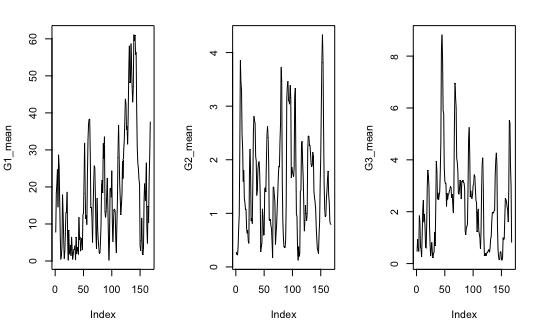

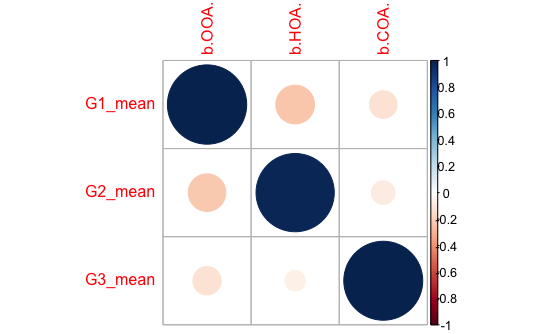

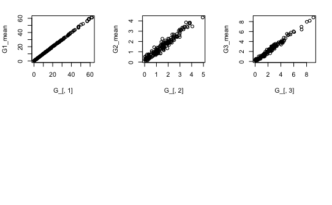

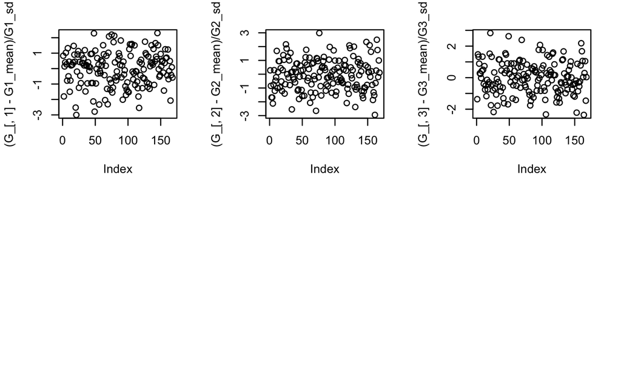

```r
quick_diagnostic_plots_with_F(fit_bamf_f)
```

## Gaussian model with F as input: BAMF_gauss

We try to see how necessary is the Cauchy prior We replace the Cauchy with a Gaussian, still, with F as data

```stan
functions {
  matrix vector_array_to_matrix(vector[] x) {
    matrix[size(x), rows(x[1])] y;
    for (m in 1:size(x))
      y[m] = x[m]';
    return y;
  }
}

data {
  int<lower=1> n;     // number of data points
  int<lower=1> m;     // number of dimensions
  int<lower=1> p;     // number of components
  matrix[n,m] X;      // data matrix
  matrix<lower=0>[n,m] sigma;  // separate sigma for each of the observations (!)
  vector<lower=0>[n-1] timesteps; //How much time elapses between values in X (arbitrary unit, but unit choice also affects other priors)
  real<lower=0> minerr; //Minimal error
  matrix<lower=0>[p,m] F; // F used as input
}

transformed data {
  vector[n*m] Xv = to_vector(X);
  vector[n*m] sigmav = to_vector(sigma);
}

parameters {
  matrix<lower=0>[n,p] G; // score matrix
  // simplex[m] F[p]; // loadings simplex
  vector<lower=0>[p] alpha_a; // Posterior a
  vector<lower=minerr>[p] alpha_b; // Posterior b
}

model {

  // The priors for G and F are implicitly given in the parameters section,
  //  so explicitly stating them here would only lead to unnecessary calculations
  //  (uniform priors become additive constants (in logspace), that can be ignored).

  // Column-wise autocorrelation
  for(j in 1:p) {
    G[1,j] ~ normal(0,100); // the first time point regularised
    G[2:,j] ~ normal(G[:(n-1),j], alpha_a[j]*timesteps + alpha_b[j]); // gaussian
  }

  // X ~ Z = G * F
  Xv ~ normal(to_vector(G*F), sigmav);

}
```

We then sample the model

```r
quick_diagnostic_plots_with_F(fit_bamf_gauss_f)
```

## AR(1) Model

The AR-1 model

```stan
transformed data {
  vector[n*m] Xv = to_vector(X);
  vector[n*m] sigmav = to_vector(sigma);
}

parameters {
  matrix<lower=0>[n,p] G; // score matrix
  // simplex[m] F[p]; // loadings simplex
  vector[p] alpha_a; // Posterior a
  vector[p] alpha_b; // Posterior b
  real<lower=0> sigma_a[p];
}

model {

  // The priors for G and F are implicitly given in the parameters section,
  //  so explicitly stating them here would only lead to unnecessary calculations
  //  (uniform priors become additive constants (in logspace), that can be ignored).

  // Column-wise autocorrelation
  for(j in 1:p) {
    G[1,j] ~ normal(0,100); // the first time point regularised
    G[2:,j] ~ normal(alpha_a[j] + alpha_b[j]*G[:(n-1),j], sigma_a[j]); // gaussian
  }

  // X ~ Z = G * F
  Xv ~ normal(to_vector(G*F), sigmav);

}
```

```
Processing csv files: /var/folders/dm/b79x42n96dl9s8jpb4t3_9lc0000gp/T/RtmpFnrAlY/bamf_AR1-202206070759-1-7bf33b.csv, /var/folders/dm/b79x42n96dl9s8jpb4t3_9lc0000gp/T/RtmpFnrAlY/bamf_AR1-202206070759-2-7bf33b.csv, /var/folders/dm/b79x42n96dl9s8jpb4t3_9lc0000gp/T/RtmpFnrAlY/bamf_AR1-202206070759-3-7b…

Checking sampler transitions treedepth.
Treedepth satisfactory for all transitions.

Checking sampler transitions for divergences.
No divergent transitions found.

Checking E-BFMI - sampler transitions HMC potential energy.
E-BFMI satisfactory.

Effective sample size satisfactory.

Split R-hat values satisfactory all parameters.

Processing complete, no problems detected.
```

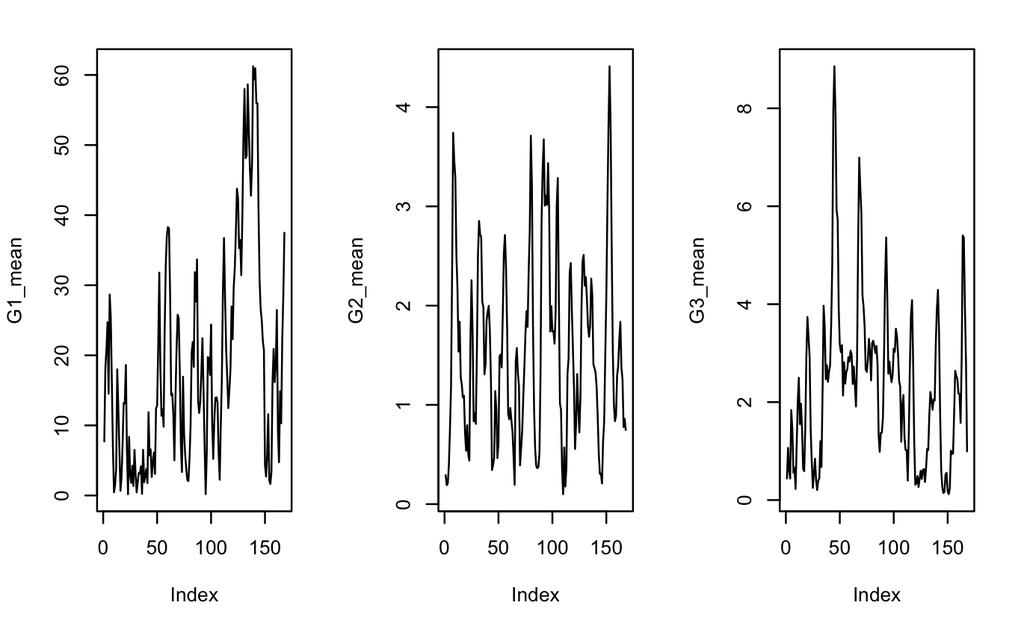

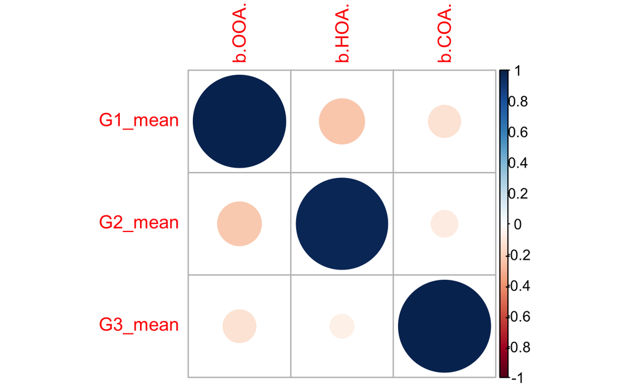

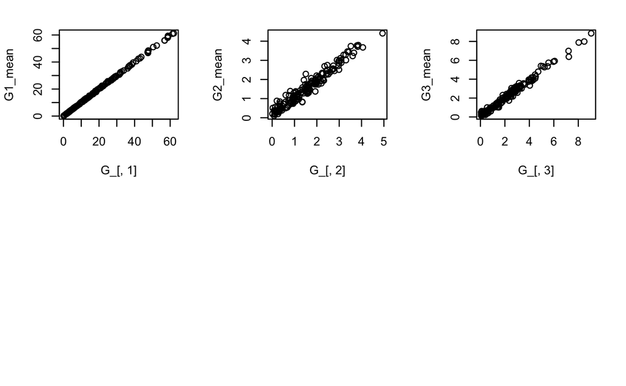

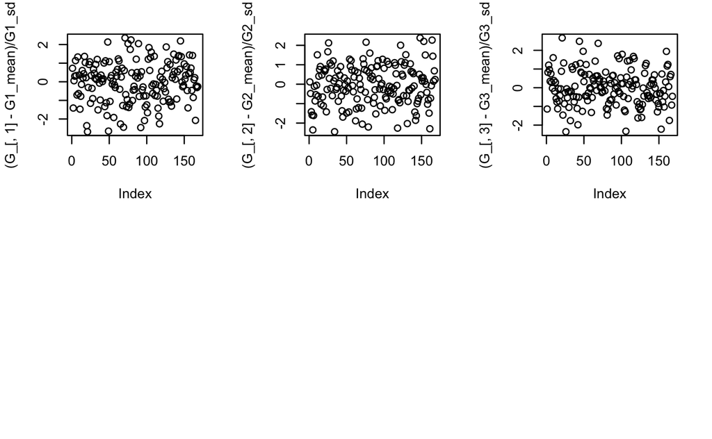

```r
quick_diagnostic_plots_with_F(fit_bamf_gauss_f)
```

## AR-1 model with no F

```r
file = "../models/bamf_AR1_no_F.stan"

mod_f <- cmdstan_model(file)
```

```r
data_list <- list(n=N, m=M , p=P, X=X_, sigma=E_, timesteps=t, minerr=
    min((E_)) / 10, F=F_
)
fit_bamf_ar1 <- mod_f$sample(
  data = data_list,
  seed = 123,
  chains = 4,
  parallel_chains = 4,
  refresh = 500 # print update every 500 iters
)
```

```
Processing csv files: /var/folders/dm/b79x42n96dl9s8jpb4t3_9lc0000gp/T/RtmpFnrAlY/bamf_AR1_no_F-202206070810-1-5d0329.csv, /var/folders/dm/b79x42n96dl9s8jpb4t3_9lc0000gp/T/RtmpFnrAlY/bamf_AR1_no_F-202206070810-2-5d0329.csv, /var/folders/dm/b79x42n96dl9s8jpb4t3_9lc0000gp/T/RtmpFnrAlY/bamf_AR1_no_F-20…

Checking sampler transitions treedepth.
Treedepth satisfactory for all transitions.

Checking sampler transitions for divergences.
1 of 4000 (0.03%) transitions ended with a divergence.
These divergent transitions indicate that HMC is not fully able to explore the posterior distribution.
Try increasing adapt delta closer to 1.
If this doesn't remove all divergences, try to reparameterize the model.

Checking E-BFMI - sampler transitions HMC potential energy.
E-BFMI satisfactory.

The following parameters had fewer than 0.001 effective draws per transition:
  G[1,1], G[2,1], G[3,1], G[4,1], G[5,1], G[6,1], G[7,1], G[8,1], G[9,1], G[10,1], G[11,1], G[12,1], G[13,1], G[14,1], G[15,1], G[16,1], G[17,1], G[18,1], G[19,1], G[20,1], G[21,1], G[22,1], G[23,1], G[24,1], G[25,1], G[26,1], G[27,1], G[28,1], G[29,1], G[30,1], G[31,1], G[32,1], G[33,1], G[34,1], G…
Such low values indicate that the effective sample size estimators may be biased high and actual performance may be substantially lower than quoted.

The following parameters had split R-hat greater than 1.05:
  G[1,1], G[2,1], G[3,1], G[4,1], G[5,1], G[6,1], G[7,1], G[8,1], G[9,1], G[10,1], G[11,1], G[12,1], G[13,1], G[14,1], G[15,1], G[16,1], G[17,1], G[18,1], G[19,1], G[20,1], G[21,1], G[22,1], G[23,1], G[24,1], G[25,1], G[26,1], G[27,1], G[28,1], G[29,1], G[30,1], G[31,1], G[32,1], G[33,1], G[34,1], G…
Such high values indicate incomplete mixing and biased estimation.
You should consider regularizating your model with additional prior information or a more effective parameterization.

Processing complete.
```

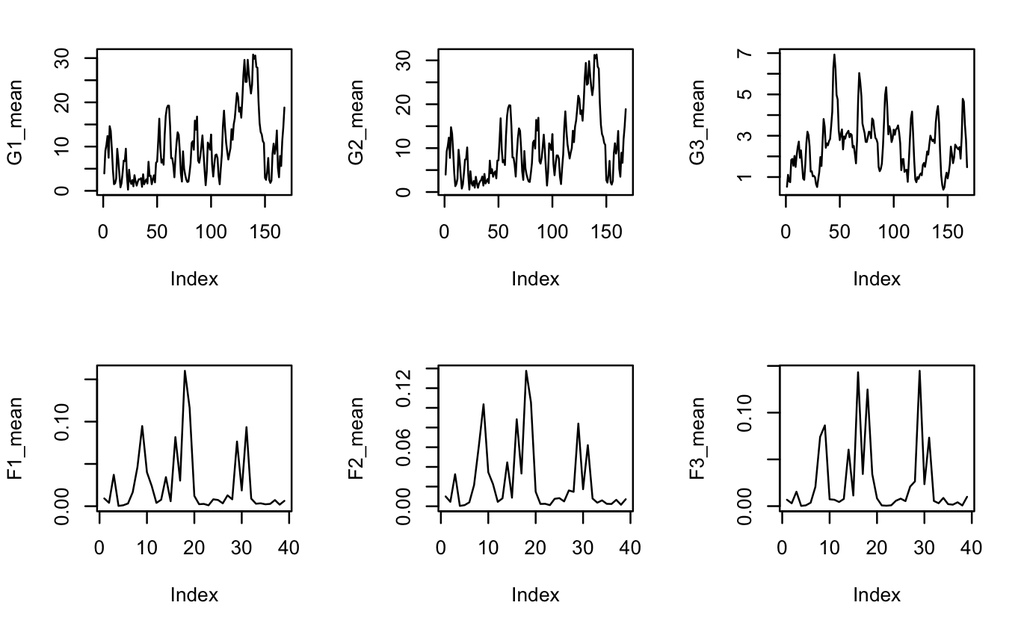

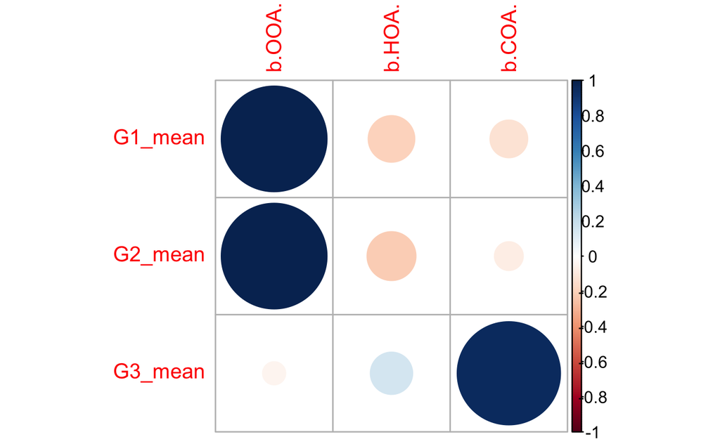

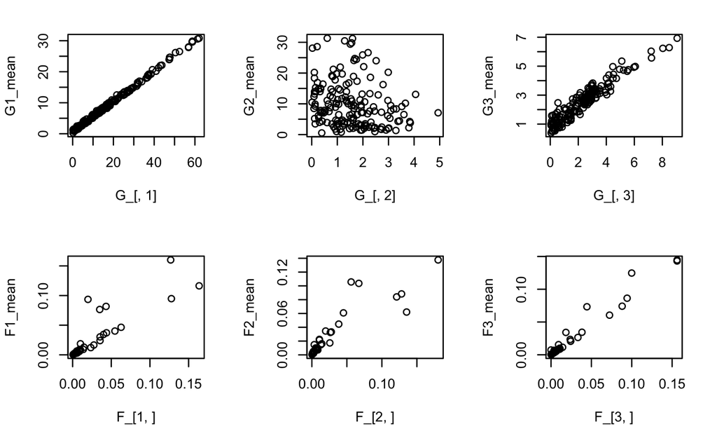

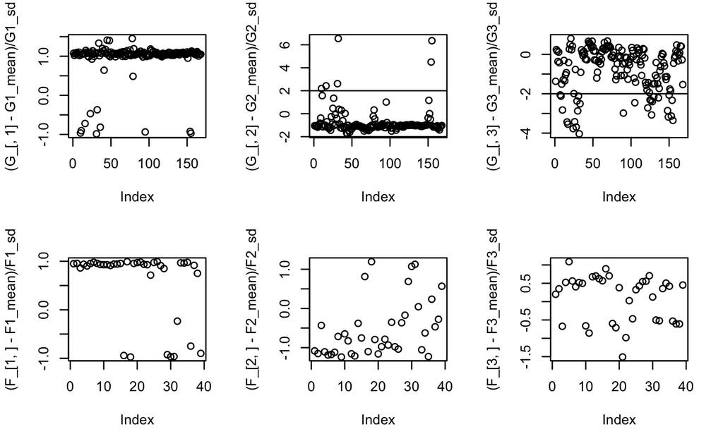

```r
quick_diagnostic_plots(fit_bamf_ar1)
```

### Conclussions

Tha Cauchy is not necessary to capture the dynamics (at least assuming completely observed data)

## BAMF with restricted G: bamf_restrictedG

Jimeng suggests adding a constraint on the sum over G matrix

```stan
functions {
  matrix vector_array_to_matrix(vector[] x) {
    matrix[size(x), rows(x[1])] y;
    for (m in 1:size(x))
      y[m] = x[m]';
    return y;
  }

  # limit the G value by the sum of X matrix on row, the total concentration of every measured chemical
  # should be larger than the G value at time point t.
  matrix get_g_max(matrix x,int n,int p) {
    matrix[n,p] y;
    for (i in 1:n)
      for (j in 1:p)
        y[i][j] = sum(x[i])*2;
    return y;
  }

}


data {
  int<lower=1> n;     // number of data points
  int<lower=1> m;     // number of dimensions
  int<lower=1> p;     // number of components
  matrix[n,m] X;      // data matrix
  matrix<lower=0>[n,m] sigma;  // separate sigma for each of the observations (!)
  vector<lower=0>[n-1] timesteps; //How much time elapses between values in X (arbitrary unit, but unit choice also affects other priors)
  real<lower=0> minerr; //Minimal error

}

transformed data {
  vector[n*m] Xv = to_vector(X);
  vector[n*m] sigmav = to_vector(sigma);
  matrix[n,p] G_max = get_g_max(X,n,p);
}

parameters {
  matrix<lower=0,upper=1>[n,p] G_raw; // raw score matrix
  simplex[m] F[p]; // loadings simplex
  vector<lower=0>[p] alpha_a; // Posterior a
  vector<lower=minerr>[p] alpha_b; // Posterior b

}

transformed parameters {
  matrix[n,p] G = (G_max) .* G_raw; // limited score matrix
}

model {

  // The priors for G and F are implicitly given in the parameters section,
  //  so explicitly stating them here would only lead to unnecessary calculations
  //  (uniform priors become additive constants (in logspace), that can be ignored).

  // Column-wise autocorrelation
  for(j in 1:p) {
    // G[2:,j] ~ cauchy(G[:(n-1),j], alpha_a[j]*timesteps + alpha_b[j]);
    target += cauchy_lpdf(G[2:,j] | G[:(n-1),j], alpha_a[j]*timesteps + alpha_b[j]);
  }

  // X ~ Z = G * F
  // Xv ~ normal(to_vector(G*vector_array_to_matrix(F)), sigmav);
  target += normal_lpdf(Xv | to_vector(G*vector_array_to_matrix(F)), sigmav);

}
```

We will use Jimeng proposal of a restricted G matrix

```r
quick_diagnostic_plots(fit_bamf_restricted)
```

## BAMF with sparsity constraints in the F matrix

We enforce some sparsity constraints by ways of the Dirichlet matrix (technically we use a Symmetric sparse Dirichlet prior)

```stan
functions {
  matrix vector_array_to_matrix(vector[] x) {
    matrix[size(x), rows(x[1])] y;
    for (m in 1:size(x))
      y[m] = x[m]';
    return y;
  }
}

data {
  int<lower=1> n;     // number of data points
  int<lower=1> m;     // number of dimensions
  int<lower=1> p;     // number of components
  matrix[n,m] X;      // data matrix
  matrix<lower=0>[n,m] sigma;  // separate sigma for each of the observations (!)
  vector<lower=0>[n-1] timesteps; //How much time elapses between values in X (arbitrary unit, but unit choice also affects other priors)
  real<lower=0> minerr; //Minimal error
  vector[m] concentration;
}

transformed data {
  vector[n*m] Xv = to_vector(X);
  vector[n*m] sigmav = to_vector(sigma);

}

parameters {
  matrix<lower=0>[n,p] G; // score matrix
  simplex[m] F[p]; // loadings simplex
  vector<lower=0>[p] alpha_a; // Posterior a
  vector<lower=minerr>[p] alpha_b; // Posterior b
}

model {

  // The priors for G and F are implicitly given in the parameters section,
  //  so explicitly stating them here would only lead to unnecessary calculations
  //  (uniform priors become additive constants (in logspace), that can be ignored).

  // Column-wise autocorrelation
  for(j in 1:p) {
    F[j] ~ dirichlet(concentration); // sparsity induced by small concent.
    G[1,j] ~ normal(0,100);
    G[2:,j] ~ cauchy(G[:(n-1),j], alpha_a[j]*timesteps + alpha_b[j]);
  }

  // X ~ Z = G * F
  Xv ~ normal(to_vector(G*vector_array_to_matrix(F)), sigmav);

}
```

We sample with 0.1 concentration parameter

```r
quick_diagnostic_plots(fit_bamf_sparse)
```

# Using MAP as init

## Original BAMF

We examine the quality of the MAP solution for the original model

```r
quick_diagnostic_plots_MAP(fit_bamf_map)
```

## BAMF with gaussians

The same, we examine the MAP results for Gaussians with unknown F

```r
quick_diagnostic_plots_MAP(fit_bamf_gauss_noF_map)
```

# Let’s use the varimax rotations as init

The MAP solutions do not seem very promising as init, we could use the latent G inferred by Varimax, but as the plot shown, they are in a different scale than the original G.

Instead I will map the inferred F by Varimax into a simplex by softmax transform, and use it to init F

```r
F_init = as.matrix(fa$Y)
F_init = apply(F_init,MARGIN =2, function(x){exp(x)/sum(exp(x))})
F_init = t(F_init)

inits_chain1 <- list(F=F_init )
inits_chain2 <- list(F=F_init )
inits_chain3 <- list(F=F_init )
inits_chain4 <- list(F=F_init )

corrplot(cor(t(F_),t(F_init)))
```

```r
inits_list = list(inits_chain1,inits_chain2,inits_chain3,inits_chain4)
fit_bamf_init <- mod_f$sample(
  data = data_list,
  seed = 123,
  chains = 4,
  parallel_chains = 4,
  refresh = 500, # print update every 500 iters
  init=inits_list
)
```

```r
quick_diagnostic_plots(fit_bamf_init)
```

# Let’s use the varimax rotations as F

```r
file = "../models/bamf_gauss.stan"

mod_f <- cmdstan_model(file)
data_list <- list(n=N, m=M , p=P, X=X_, sigma=E_, timesteps=t, minerr=
    min((E_)) / 10, F=F_init
)
fit_bamf_gauss_f <- mod_f$sample(
  data = data_list,
  seed = 123,
  chains = 4,
  parallel_chains = 4,
  refresh = 500 # print update every 500 iters
)
```

```r
quick_diagnostic_plots_with_F(fit_bamf_gauss_f)
```

# Conclusions

- The Cauchy prior may not be necessary to infer the time patterns.
- There are identifiability issues. Seems like the label switching issue in mixture models, Two columns of G are sampling the same latent variable leaving one unidentified.
- Probably a prior that disambiguates the columns of the simplex or the time profiles could alleviate this.